# 11 DIF analysis

WHO Technical Training

Carolina Fellinghauer

fellinghauerc@who.int

April 2021

# Getting ready

Please include the following libraries:

```r
# install and load following R-packages

library(eRm)
library(iarm)
library(PP)  #used by the anova_DIF function
```

and load the Stress Related Growth data (SRG) :

```r
urlfile <- "https://raw.githubusercontent.com/CarolinaFellinghauer/WHO_Training_Rasch/main/Data/SRG_Data_Course_UZH_HS2021.csv"

srg.data <- read.csv(url(urlfile))


dim(srg.data)
```

```
[1] 450  26
```

```r
colnames(srg.data)
```

```
 [1] "X"                      "ID"                     "Age"
 [4] "Gender"                 "Completeness"           "para.tetra_1"
 [7] "traumatic_nontraumatic" "PersStat"               "SRG1"
[10] "SRG2"                   "SRG3"                   "SRG4"
[13] "SRG5"                   "SRG6"                   "SRG7"
[16] "SRG8"                   "SRG9"                   "SRG10"
[19] "SRG11"                  "SRG12"                  "SRG13"
[22] "SRG14"                  "SRG15"                  "TP"
[25] "ID_Unik"                "wgt"
```

```r
srg.items <- c("SRG1", "SRG2", "SRG3", "SRG4", "SRG5", "SRG6", "SRG7", "SRG8", "SRG9",
    "SRG10", "SRG11", "SRG12", "SRG13", "SRG14", "SRG15")

# create age groups based < 30 < 45 < 60 < the break choice here is, admittedly,
# a bit random

srg.data[, "Age_grp"] <- cut(srg.data[, "Age"], breaks = c(0, 30, 45, 60, 85))

# exogenous variables to test DIF for
srg.pf <- c("Age", "Age_grp", "Gender", "Completeness", "para.tetra_1", "traumatic_nontraumatic")

# dataset with SRG items and the person factors
data.srg <- srg.data[, c(srg.items, srg.pf)]

# check response coding (frequencies including missing values) for each SRG-item
# apply(data.srg, 2, table, useNA='always')

# recode traumatic_nontraumatic = 3 to NA

data.srg[which(data.srg[, "traumatic_nontraumatic"] == 3), "traumatic_nontraumatic"] <- NA
```

# Differential Item Functioning

The items’ invariance to group effects is tested through a so called Differential Item Functioning (DIF) procedure. Given an ability level, the response to an item should be the same, irrespective of group membership (e.g. gender, age…).

DIF indicates the lack of invariance of an item difficulty to an exogenous variable (Boone, Staver, and Yale 2014). In general, it is understood that DIF occurs when sample subgroups respond differently to an individual item despite equal level of ability. For example, in a math examination, independently of their level in maths, participants who are not fluent in the language of the examination may be penalized. These systematic differences in the responses can be problematic as they indicate that the questionnaire is not fair across the complete sample and comparisons across subgroups can be problematic. For example, in an educational test with DIF, items may disadvantage one subgroup against the other. In principle, items with DIF could make a scale unsuitable for measurement and comparisons across a population. But, it is not so simple.

To understand DIF, the person map below may be helpful. This figure is invented and should represent the outcome of a Rasch analysis of a 5 item scale, with 3 response options. The sample consists of 10’000 persons, which can be divided into 2 subgroups A and B (for example: male versus female, below versus above 50 years, working not working).

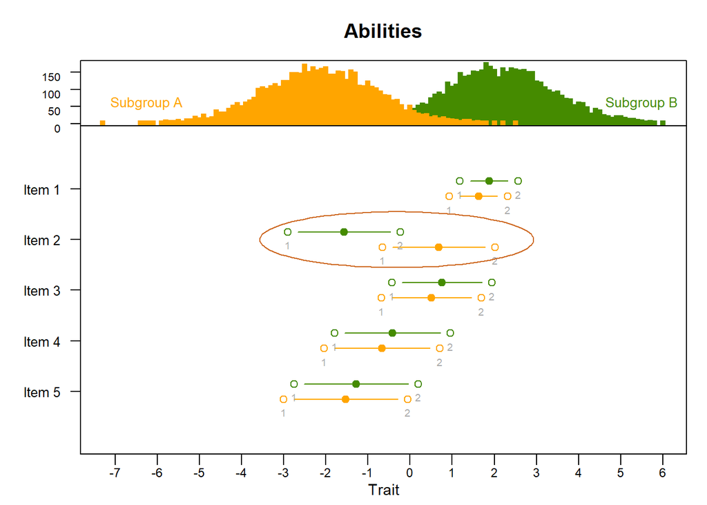

They are two observations with regard to the person item map above. First, the Subgroup B has significantly higher ability than Subgroup A. The differences in ability between the Subgroup A and the Subgroup B may not be measurement bias. In that sense, observing a difference in the mean location of sample subgroups is not evidence of problems with the construct validity.  
Second, except for *Item 2* all items have similar item difficulty for Subgroup A and Subgroup B. *Item 2* as can be seen is perceived as more difficult by the Subgroup A, as shown by the higher item difficulty. *Item 2* exhibits DIF, for a given level of ability, the response difficulty is very different between Subgroup A and Subgroup B. It is not likely that the shift in ability is caused by the difference in difficulty see in *Item 2*.

Items are checked for DIF for exogenous variables, i.e. person or sample characteristics, typically for ‘age group’, ‘gender’, but also for ‘educational level’, ‘health condition’, ‘country’, ‘language’, ‘survey year’, etc. The decision on which sample characteristics to test for item DIF is left to the researcher. However, a sufficient number of cases in the subgroups, with responses to the items response options, are necessary to perform a reliable DIF analysis.

If an item shows DIF, the item can be either removed, split or the model has to be extended to take into account the DIF (ex. multi-group analysis). There are two types of DIF: uniform and non-uniform DIF. Uniform DIF means that the difference between some subgroups is consistent over the range of ability levels, non-uniform DIF means inconsistent differences.

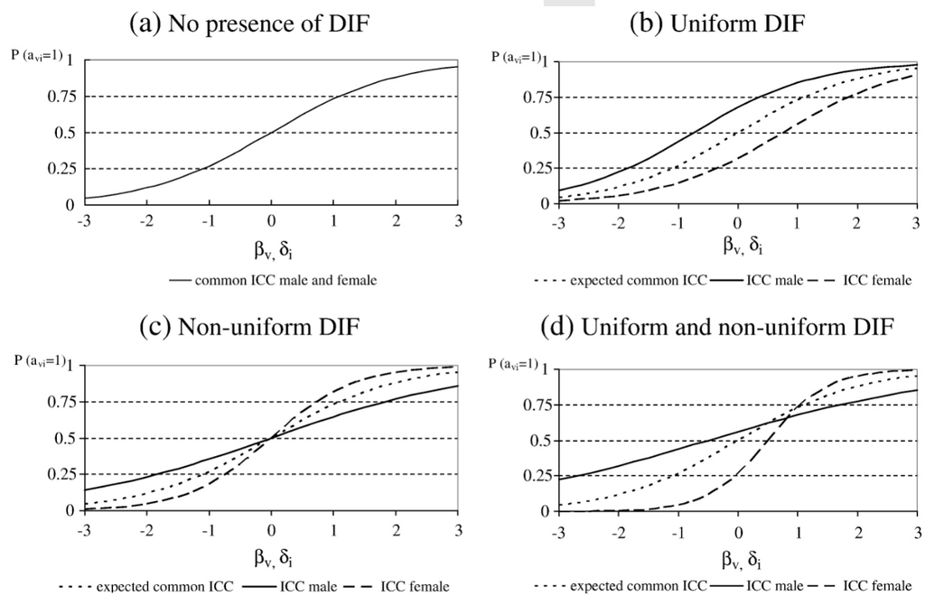

Example : DIF-Types

The example shows ICC curves, with the response probability for a dichotomous questionnaire item given an ability level. The expected response probability is shown for the sample with the dotted curve, a curve for female participants (dashed), and a curve for male participants (continuous) (Salzberger, Newton, and Ewing 2014). In absence of DIF, the subgroup lines are close to each other, following the expected probability curve. In uniform DIF, the curves are parallel with one subgroup systematically above the other. With non-uniform DIF the subgroup lines cross, with higher abilities of a subgroup in the lower score levels and higher abilities for the other subgroup in the higher score levels.

There are many different ways to test for DIF, what follows presents only one approach which is applicable for dichotomous as well as polytomous item types, the two-way ANOVA of the residuals.

# Diagnostics

## Numeric Output Analysis

### Two-way ANOVA

What follows shows one approach to detect DIF, i.e. an analysis of the residuals with ANOVA. Unfortunately, the package `eRm` does not contain functions for DIF analysis with polytomous data, only for dichotomous items (`LRtest` & `plotDIF`).

ANOVA or analysis of variance is a statistical approach that is interested in the “variation” among and between groups to analyze the differences among subgroup means in a sample.

A two-way ANOVA tests the effect of two grouping variables on the outcome. The outcome in this setting would be the residuals of a Rasch analysis. Such a function is found here for :

```r
urldif <- "https://raw.githubusercontent.com/CarolinaFellinghauer/WHO_Training_Rasch/main/RFunctions/anova_DIF.r"

source(url(urldif))
```

The grouping variables would be a person factor and the class interval (`ci`). The `ci` refers to the total score. In fact, participants are grouped according to their total score, called `ci` groups - from low to high `ci`. The `ci` are built equally sized, i.e. with more or less same number of partipants per `ci`. The number of `ci` depends on the sample size, with approximately 30-50 cases per `ci`.

In the SRG-dataset, the exogenous or DIF-variables chosen to show how to run a DIF analysis are `Gender` and `para_tetra_1`, the level of the spinal cord injury.

The two-way ANOVA would test, per item, the mean residual differences across the person factor, the `ci` (’ = uniform DIF’) and the interaction of the person factor and the `ci` (’ = non-uniform DIF’).

With a sample size of N = 450, to have around 50 people per score class interval, can be achieved with about 9 of `ci`, with the option `nci=`.

```r
DIF.srg.gender = anova_DIF(data.srg[,srg.items],
                    data.srg$Gender,
                    model = "PCM",
                    nci = 9,  #number of score class interval
                    p.adj="BH") #correction for multiple testing
DIF.srg.gender
```

```
$`data.srg$Gender`
$`data.srg$Gender`$SRG1
                       Df Sum Sq Mean Sq F value p.adj.BH
ci                      8   22.7   2.835   3.393  0.03894
data.srg$Gender         1    5.2   5.236   6.266  0.27741
ci:data.srg$Gender      8   15.6   1.949   2.333  0.27741
Residuals             420  350.9   0.836
3 observations deleted due to missingness

$`data.srg$Gender`$SRG2
                       Df Sum Sq Mean Sq F value p.adj.BH
ci                      8   36.3   4.542   4.152   0.0039
data.srg$Gender         1    0.0   0.001   0.001   1.0000
ci:data.srg$Gender      8   16.8   2.102   1.922   1.0000
Residuals             420  459.4   1.094
3 observations deleted due to missingness

$`data.srg$Gender`$SRG3
                       Df Sum Sq Mean Sq F value p.adj.BH
ci                      8   13.7   1.717   1.692   1.0000
data.srg$Gender         1    6.2   6.221   6.131   0.3078
ci:data.srg$Gender      8   30.7   3.832   3.776   0.0123
Residuals             417  423.2   1.015
6 observations deleted due to missingness

$`data.srg$Gender`$SRG4
                       Df Sum Sq Mean Sq F value p.adj.BH
ci                      8   25.5   3.184   3.800   0.0114
data.srg$Gender         1    0.0   0.004   0.004   1.0000
ci:data.srg$Gender      8    6.7   0.842   1.005   1.0000
Residuals             420  351.9   0.838
3 observations deleted due to missingness

$`data.srg$Gender`$SRG5
                       Df Sum Sq Mean Sq F value p.adj.BH
ci                      8   14.5  1.8182   2.197   0.6024
data.srg$Gender         1    1.9  1.9193   2.319   1.0000
ci:data.srg$Gender      8   20.2  2.5280   3.054   0.1064
Residuals             420  347.6  0.8277
3 observations deleted due to missingness
```

[output cut: 65 more lines]

```
$`data.srg$Gender`$SRG14
                       Df Sum Sq Mean Sq F value p.adj.BH
ci                      8  16.32  2.0404   2.849   0.0968
data.srg$Gender         1   0.03  0.0293   0.041   1.0000
ci:data.srg$Gender      8  24.34  3.0420   4.247   0.0029
Residuals             422 302.27  0.7163
1 observation deleted due to missingness

$`data.srg$Gender`$SRG15
                       Df Sum Sq Mean Sq F value p.adj.BH
ci                      8   69.8   8.722   6.040   0.0000
data.srg$Gender         1    4.9   4.914   3.403   0.9867
ci:data.srg$Gender      8   30.9   3.868   2.679   0.1578
Residuals             421  607.9   1.444
2 observations deleted due to missingness
```

Now, the injury level, paraplegia versus tetraplegia is tested for DIF. Let’s assume a difference in the stress related growth between persons with paraplegia or tetraplegia can bias the scale. Paraplegia often results in loss of sensation or paralysis of the lower body part. Persons with tetraplegia have the upper body part which is paralized or lacks of sensations.

```r
DIF.srg.level <- anova_DIF(data.srg[, srg.items], data.srg$para.tetra_1, model = "PCM",
    nci = 9, p.adj = "BH")  #correction for multiple testing
DIF.srg.level
```

```
$`data.srg$para.tetra_1`
$`data.srg$para.tetra_1`$SRG1
                          Df Sum Sq Mean Sq F value p.adj.BH
ci                         8   22.2   2.780   3.410   0.0187
data.srg$para.tetra_1      1    1.1   1.052   1.290   1.0000
ci:data.srg$para.tetra_1   8   34.4   4.302   5.278   0.0001
Residuals                399  325.2   0.815
24 observations deleted due to missingness

$`data.srg$para.tetra_1`$SRG2
                          Df Sum Sq Mean Sq F value p.adj.BH
ci                         8   45.5   5.693   5.508   0.0001
data.srg$para.tetra_1      1    0.0   0.024   0.023   1.0000
ci:data.srg$para.tetra_1   8   35.3   4.411   4.268   0.0014
Residuals                399  412.4   1.034
24 observations deleted due to missingness

$`data.srg$para.tetra_1`$SRG3
                          Df Sum Sq Mean Sq F value p.adj.BH
ci                         8   11.9  1.4857   1.427   1.0000
data.srg$para.tetra_1      1    0.1  0.0522   0.050   1.0000
ci:data.srg$para.tetra_1   8   23.0  2.8743   2.760   0.2524
Residuals                396  412.4  1.0414
27 observations deleted due to missingness

$`data.srg$para.tetra_1`$SRG4
                          Df Sum Sq Mean Sq F value p.adj.BH
ci                         8  24.34   3.042   4.120   0.0022
data.srg$para.tetra_1      1   0.94   0.938   1.270   1.0000
ci:data.srg$para.tetra_1   8  51.54   6.443   8.725   0.0000
Residuals                399 294.63   0.738
24 observations deleted due to missingness

$`data.srg$para.tetra_1`$SRG5
                          Df Sum Sq Mean Sq F value p.adj.BH
ci                         8   15.4  1.9272   2.301   0.4566
data.srg$para.tetra_1      1    1.7  1.6843   2.011   1.0000
ci:data.srg$para.tetra_1   8   19.7  2.4630   2.940   0.1500
Residuals                399  334.3  0.8377
24 observations deleted due to missingness
```

[output cut: 65 more lines]

```
$`data.srg$para.tetra_1`$SRG14
                          Df Sum Sq Mean Sq F value p.adj.BH
ci                         8  14.09   1.762   2.330   0.4211
data.srg$para.tetra_1      1   4.46   4.458   5.896   0.4211
ci:data.srg$para.tetra_1   8   9.71   1.214   1.605   1.0000
Residuals                401 303.18   0.756
22 observations deleted due to missingness

$`data.srg$para.tetra_1`$SRG15
                          Df Sum Sq Mean Sq F value p.adj.BH
ci                         8   67.6   8.446   6.241    0e+00
data.srg$para.tetra_1      1    0.0   0.007   0.005    1e+00
ci:data.srg$para.tetra_1   8   49.7   6.217   4.594    5e-04
Residuals                400  541.3   1.353
23 observations deleted due to missingness
```

The analysis with ANOVA indicates no uniform DIF for the injury level. Non-uniform DIF is observed, for *SRG1 I learned to be nicer to others*, *SRG2 I feel freer to make my own decisions*, *SRG4 I learned to be myself and not try to be what others want me to be*, *SRG8 I learned to be a more confident person*, *SRG9 I learned to listen more carefully when others talk to me*, *SRG12 I learned that I want to have some impact on the world*, and *SRG15 I learned that there are more people who care about me than I thought*.

## Visual Analysis

The following plots, which show the item difficulty estimates across separate calibrations of the SRG data for subgroups of gender and lesion type. The significantdifference in difficulty for SRG8 for gender becomes also visible in this figure.

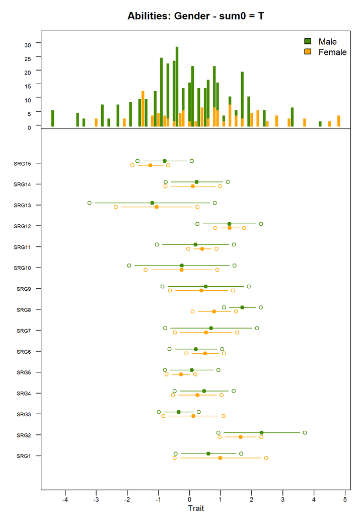

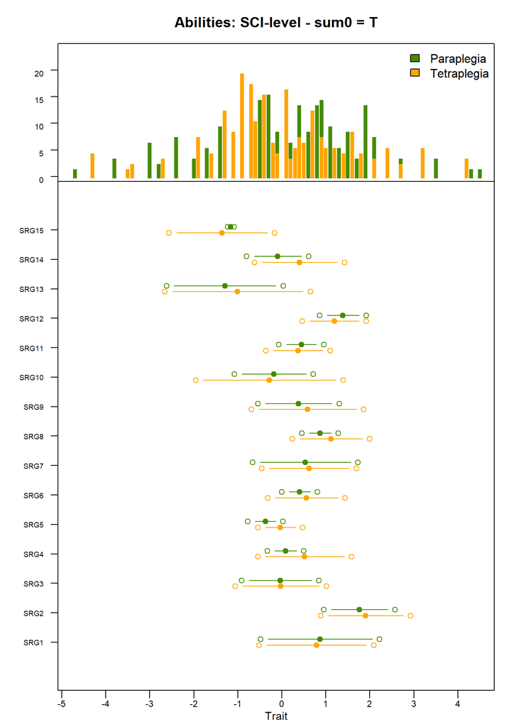

### ICC plot

The uniform DIF found in the numeric outputs is usually also visible on ICC plots with separate lines for levels of the person factor tested for. Such a function, is found in the package `iarm`. With polytomous data, instead of the response probability, the expected item score is drawn on the y-axis.

When the item is free of DIF and fitting the Rasch Model, the lines for the subgroup should fall as close as possible to the expected common score line. For example *SRG7* is free of Gender, and it is also a well fitting item.

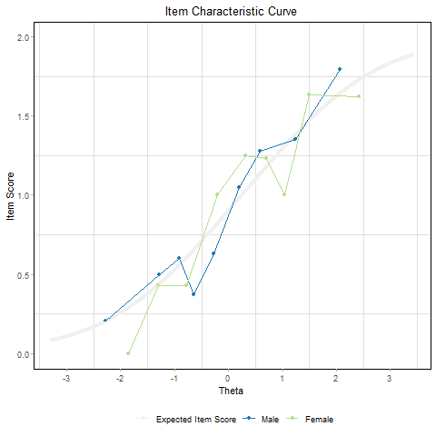

In comparison, the curves of the item *SRG8* when tested for DIF for the gender, which was significant (*p*-value = 0.0031). The lines are away from the expected curve, with the line of one group more consistently above the other.

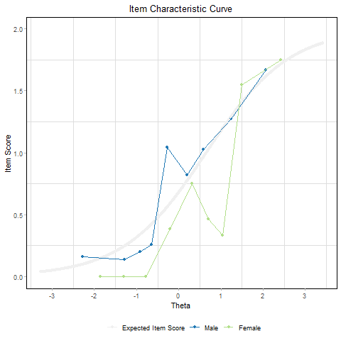

The curves of the item *SRG4* when tested for DIF for the lesion level, which was significant (*p*-value < 0.001). The lines are away from the expected curve, with the no group more consistently above the other.

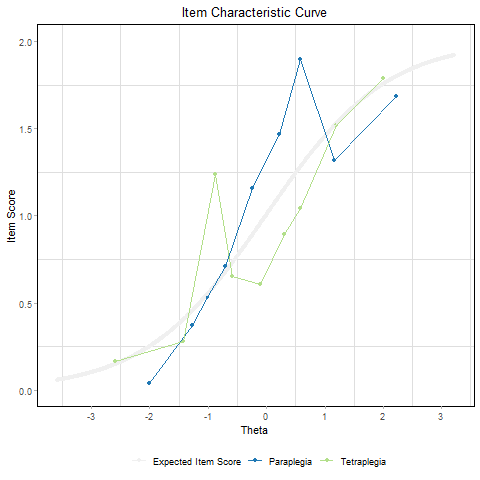

# Adjustment

In presence of uniform DIF, instead of deleting the item with DIF, the item can be split. Item split allows an item with DIF to have different difficulty estimates across subgroups. Splitting, however, will allow the difficulty of the items to differ across subgroups. As a consequence, not one psychometrically sound interval-scaled metric is developed but as many adjusted, subgroup specific metrics as subgroups that conducted to DIF.

Typically, item splitting is done stepwise, starting with the item showing the highest DIF on an exogeneous variable.

It is important to note that many methods for DIF analysis use the constraint that the mean of the item parameters is zero in each group for anchoring (in `eRm` even when the other constraint `sum0 = FALSE` is used for fitting the model). This constraint implicitly makes the assumption that DIF is balanced (some items prefer one group, some the other, and on average the DIF cancels out). However, this approach may cause so-called artificial DIF (Andrich and Hagquist 2014), i.e. smaller DIF in some items as a reaction to the large DIF in another or other items. To avoid this, so called anchor items can be selected by means of statistical procedures, but most methods for anchor item selection have been suggested only for binary Rasch models so far.

```r
# example of item split using the item 8 which showed strong DIF gender (male and
# female).

# here two new variables are created one for paraplegia and one for tetraplegia
# for each variable the options for the other injury group are set to missing.

srg.data[, "SRG8_M"] <- srg.data[, "SRG8"]
srg.data[which(srg.data[, "Gender"] == 2), "SRG8_M"] <- NA

srg.data[, "SRG8_F"] <- srg.data[, "SRG8"]
srg.data[which(srg.data[, "Gender"] == 1), "SRG8_F"] <- NA


# now instead one SRG8 item, there are two, one for the males and females.

# the item SRG10 has to be removed or the list of SRG items has to be redefined.

srg.items <- c("SRG1", "SRG2", "SRG3", "SRG4", "SRG5", "SRG6", "SRG7", "SRG8_M",
    "SRG8_F", "SRG9", "SRG10", "SRG11", "SRG12", "SRG13", "SRG14", "SRG15")

head(srg.data[, srg.items])
```

```
  SRG1 SRG2 SRG3 SRG4 SRG5 SRG6 SRG7 SRG8_M SRG8_F SRG9 SRG10 SRG11 SRG12 SRG13
1    2    1    1    2    2    2    2      2     NA    2     2     2     2     2
2    2    1    0    0    2    1    2     NA      0    0     2     2     0     2
3    1    0    0    0    1    0    0      1     NA    1     1     2     0     2
4    1    1    2    1    2    2    2      1     NA    1     1     2     1     2
5    1    1    1    2    2    2    2      1     NA    2     2     2     0     2
6   NA   NA    2    0    0    1    1      1     NA    0     0     1     1     1
  SRG14 SRG15
1     2     2
2     2     2
3     1     1
4     2     2
5     2     2
6     1     1
```

The Rasch analysis is re-run with the item *SRG8 I learned to be a more confident person* split for gender. Here, the person item map to show the distribution of the item difficulty estimates.

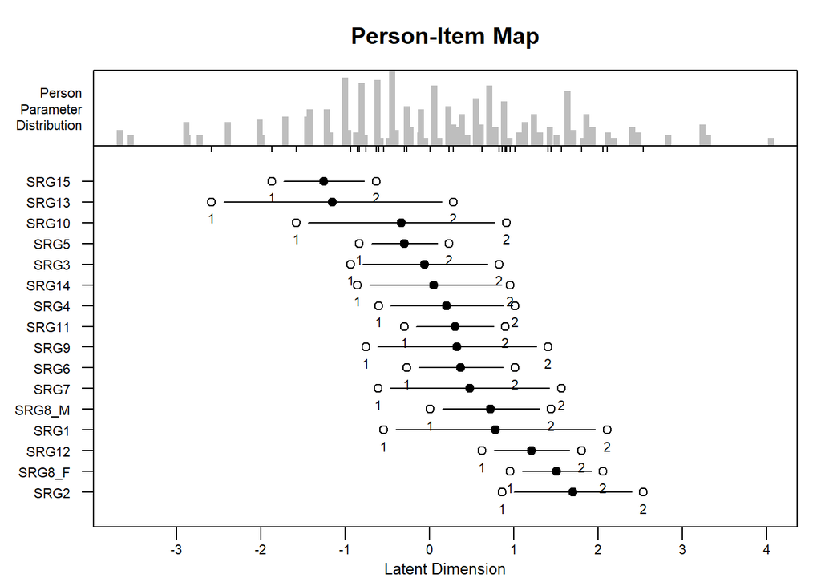

```r
plotPImap(PCM(srg.data[, srg.items]), sorted = TRUE)
```

At this stage, the Rasch analysis, has to be started from the beginning. That means, the item fit, the local item dependencies etc… are checked again… (and again)… until each assumption of the Rasch model meets the requirements.

# Exercise

Run the same DIF analysis for Age group (< 30 < 45 < 60) and injury completeness. Detect uniform DIF and decide if you would need to split items or not.

# References

Andrich, David, and Curt Hagquist. 2014. “Real and Artificial Differential Item Functioning in Polytomous Items.” *Educational and Psychological Measurement*, May. https://doi.org/10.1177/0013164414534258.

Boone, William J., John R. Staver, and Melissa S. Yale. 2014. *Rasch Analysis in the Human Sciences*.

Salzberger, Thomas, Fiona J. Newton, and Michael T. Ewing. 2014. “Detecting Gender Item Bias and Differential Manifest Response Behavior: A Rasch-Based Solution.” *Journal of Business Research* 67 (4): 598–607. https://doi.org/https://doi.org/10.1016/j.jbusres.2013.02.045.